# 10 - Model averaging and regression trees

Francisco E. Fonturbel

13/November/2025

## Dealing with multiple variables at once

Now that we learned how to conduct multivariate regressions, it’s easy to be tempted to include so many variables in our models, which creates new problems (e.g., multicollinearity caused by introducing redundant variables into the models). Fortunately, there are many approaches to deal with this kind of situations. Here we will explore model averaging and regression trees.

## Model averaging

Once we fit a model with two or more variables, we may wonder if all of those variables are important in explaining our response variable, or only a subset of those variables are really important and the remaining ones can be safely discarded. I recommend you to take a look to Burnham & Anderson’s book on this matter, which is highly enlightning about this.

To illustrate this point, we will use data from [Cordero et al. (2020)](https://www.mdpi.com/882552)

```r
library(mgcv)
library(lme4)
library(MASS)
library(lmerTest)
library(pbkrtest)
library(MuMIn)
library(corrplot)
library(ggpubr)
library(PairedData)
library(plyr)
library(ggplot2)
library(GGally)
library(tree)
library(randomForest)
library(gt)

data<-read.table("data/10_data_threat.txt",
                     header=TRUE,
                     sep="\t",
                     dec=",",
                     na.strings="NA")
attach(data)
head(data)
```

```
##        Country Continent Geography Country_size Population Pop_density
## 1      Algeria    Africa Continent      2381741   34178188       14.35
## 2       Angola    Africa Continent      1246700   12799293       10.27
## 3        Benin    Africa Continent       112622    8791832       78.06
## 4     Botswana    Africa Continent       581730    1990876        3.42
## 5 Burkina Faso    Africa Continent       274200   15746232       57.43
## 6      Burundi    Africa Continent        27830    8988091      322.96
##   Urbanization Ethnic.dominance Literacy education_GDP    GDP money_educ
## 1         0.65                1     0.70         0.051 235500    12010.5
## 2         0.57                2     0.67         0.024 110300     2647.2
## 3         0.41                2     0.35         0.044  12840      565.0
## 4         0.60                1     0.81         0.087  26040     2265.5
## 5         0.20                2     0.22         0.042  17820      748.4
## 6         0.10                1     0.59         0.051   3103      158.3
##   GDP_percapita educ_percap perc_prot_land protected_area perc_PA_2019 delta_PA
```

[output cut: 69 more lines]

We collected a huge dataset on several economic and educative metrics for 138 countries around the world and related them to the proportion of threatened species of the major vertebrate groups (I recommend you to read the paper using the link provided above if you are interested in this subject).

First we should examine how our variables are correlated:

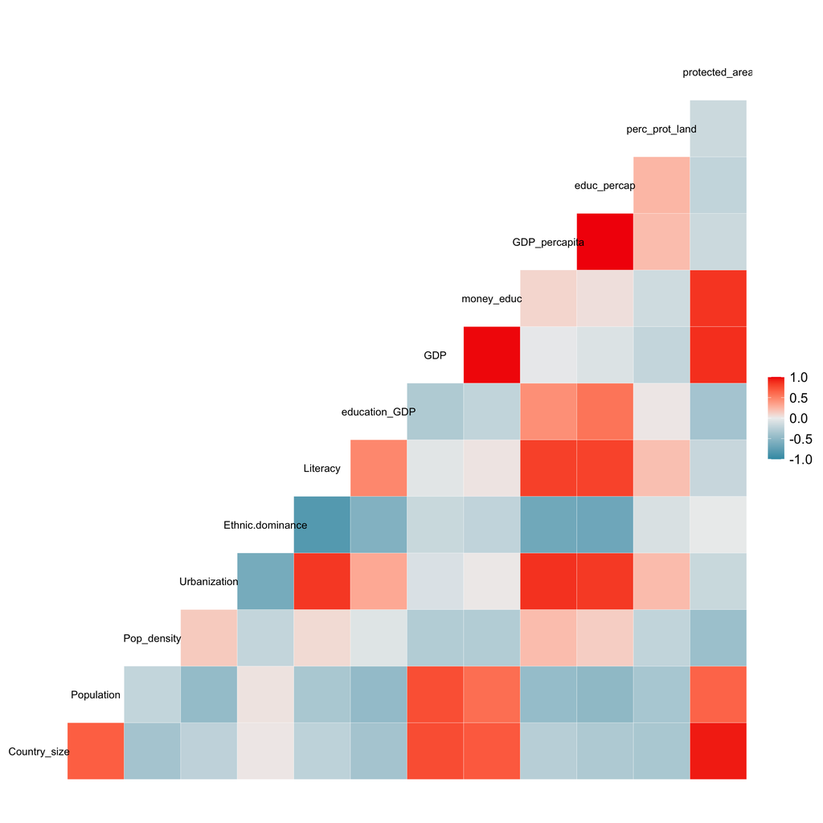

```r
My_Theme = theme(
  plot.caption = element_text(size = 14),
  legend.text = element_text(size = 14))

source("multiplot.R")
mm<-stats::cor(data[,4:16], use="pairwise.complete.obs")
corcov<-ggcorr(data = NULL, cor_matrix = cor(mm, use = "everything")) +
  My_Theme

multiplot(corcov)
```

As expected, we have a lot of variables and some of them are highly correlated.

Before start making models, we should transform our response variables as they are proportions:

```r
#Data transforming for proportions
tmamm17<-log(prop_thr_mammals17/(1-prop_thr_mammals17))

#making some transformation por percentage of protected land first
perc_prot_land<-log(perc_prot_land+1)
```

Let’s see what happens to mammals:

```r
thr_mamm_2017<-lmer(tmamm17~Urbanization+Pop_density+Literacy+education_GDP+money_educ+perc_prot_land+protected_area+(1 | Geography), na.action = "na.fail")
summary(thr_mamm_2017, ddf="Kenward-Roger")
```

```
## Linear mixed model fit by REML. t-tests use Kenward-Roger's method [
## lmerModLmerTest]
## Formula: tmamm17 ~ Urbanization + Pop_density + Literacy + education_GDP +
##     money_educ + perc_prot_land + protected_area + (1 | Geography)
##
## REML criterion at convergence: 369.1
##
## Scaled residuals:
##     Min      1Q  Median      3Q     Max
## -3.4195 -0.5629  0.0534  0.5363  3.1456
##
## Random effects:
##  Groups    Name        Variance Std.Dev.
##  Geography (Intercept) 0.4962   0.7044
##  Residual              0.5165   0.7187
## Number of obs: 138, groups:  Geography, 2
##
## Fixed effects:
##                  Estimate Std. Error         df t value Pr(>|t|)
## (Intercept)    -4.654e-01  5.899e-01  1.792e+00  -0.789  0.52104
## Urbanization   -9.626e-02  3.461e-01  1.290e+02  -0.278  0.78136
## Pop_density     3.117e-05  1.129e-04  1.296e+02   0.276  0.78296
## Literacy       -8.785e-01  3.858e-01  1.293e+02  -2.277  0.02442 *
## education_GDP  -6.993e+00  3.253e+00  1.290e+02  -2.150  0.03345 *
## money_educ     -8.300e-07  1.275e-06  1.290e+02  -0.651  0.51626
## perc_prot_land -2.079e-01  7.235e-02  1.290e+02  -2.874  0.00475 **
## protected_area  8.211e-07  5.336e-07  1.291e+02   1.539  0.12633
## ---
## Signif. codes:  0 '***' 0.001 '**' 0.01 '*' 0.05 '.' 0.1 ' ' 1
##
## Correlation of Fixed Effects:
##             (Intr) Urbnzt Pp_dns Litrcy ed_GDP mny_dc prc_p_
## Urbanizatin -0.026
## Pop_density -0.080 -0.141
## Literacy    -0.293 -0.550  0.053
## educatn_GDP -0.172  0.028  0.073 -0.215
## money_educ   0.060 -0.070 -0.031 -0.069 -0.055
## prc_prt_lnd -0.172 -0.013  0.053 -0.113  0.079  0.018
## protected_r -0.018 -0.035  0.070  0.037  0.081 -0.705 -0.123
## fit warnings:
## Some predictor variables are on very different scales: consider rescaling
```

So, we have several variables in the models, some have significant effects but other don’t. So, which variables are the most relevant in this case?

### The Akaike information criterion (AIC) and its relatives

The Akaike Information Criterion (AIC) is a metric that balances model fit against complexity by penalizing models with more parameters, helping you select the most parsimonious model among competing alternatives.

**AIC = 2k - 2ln(L)**

where:

k = number of estimated parameters in the model L = maximum likelihood value of the model

Lower AIC values indicate better models!

Other common variations are:

- AICc = AIC corrected for small sample sizes (N ≤ 20).
- BIC = Bayesian Information Criterion, penalizes model complexity more severely.
- qAIC = Quasi-AIC applies for models with overdispersion. Particularly useful when working with generalized linear models (GLMs) where variance assumptions are violated—very common in ecological datasets with count or binomial data.

### Model selection

We will use the `dredge` function from the `MuMIn` library to produce all possible models (yes, they are way too many to do this by hand!). There are different options to rank model performance, the most common is the Akaike Information Criterion (AIC) that have lower values when models perform better. In this case we will use the Bayesian Information Criterion (BIC), which works in a similar way. We will consider only those models with a delta BIC < 5 (models with larger differences explain very little of the variance and can be discarded).

```r
mamm3<-dredge(thr_mamm_2017, rank = BIC)
mamm3s<-subset(mamm3, delta <5)
#mamm3
```

```r
mamm3s %>%
  as.data.frame() %>%
  gt() %>%
  fmt_number(columns = c(BIC, delta, weight), decimals = 2)
```

| (Intercept) | education_GDP | Literacy | money_educ | perc_prot_land | Pop_density | protected_area | Urbanization | df | logLik | BIC | delta | weight |
| --- | --- | --- | --- | --- | --- | --- | --- | --- | --- | --- | --- | --- |
| -0.7285533 | -6.661209 | -1.0524132 | NA | NA | NA | NA | NA | 5 | -152.9098 | 330.46 | 0.00 | 0.54 |
| -0.4679563 | -7.424563 | -0.9158277 | NA | -0.1908908 | NA | NA | NA | 6 | -151.0888 | 331.74 | 1.29 | 0.29 |
| -0.9122955 | NA | -1.2025778 | NA | NA | NA | NA | NA | 4 | -157.0628 | 333.83 | 3.38 | 0.10 |
| -1.0902493 | -9.682271 | NA | NA | -0.2241060 | NA | NA | NA | 5 | -154.9486 | 334.53 | 4.08 | 0.07 |

Now that we have our models, we see that none of them explained >80% of the variance alone (this can be found in the “weight” column), we will estimate the importance of each parameter by summing the weights of all models including a given variable and then representing it using a barplot:

```r
get.models(mamm3, subset = delta < 2)
```

```
## $`4`
## Linear mixed model fit by REML ['lmerModLmerTest']
## Formula: tmamm17 ~ education_GDP + Literacy + (1 | Geography)
## REML criterion at convergence: 305.8195
## Random effects:
##  Groups    Name        Std.Dev.
##  Geography (Intercept) 0.7187
##  Residual              0.7317
## Number of obs: 138, groups:  Geography, 2
## Fixed Effects:
##   (Intercept)  education_GDP       Literacy
##       -0.7286        -6.6612        -1.0524
##
## $`12`
## Linear mixed model fit by REML ['lmerModLmerTest']
## Formula: tmamm17 ~ education_GDP + Literacy + perc_prot_land + (1 | Geography)
## REML criterion at convergence: 302.1775
## Random effects:
##  Groups    Name        Std.Dev.
##  Geography (Intercept) 0.6883
##  Residual              0.7155
## Number of obs: 138, groups:  Geography, 2
## Fixed Effects:
##    (Intercept)   education_GDP        Literacy  perc_prot_land
##        -0.4680         -7.4246         -0.9158         -0.1909
##
## attr(,"rank")
## function (x)
## do.call("rank", list(x))
## <environment: 0x1222da898>
## attr(,"call")
## BIC(x)
## attr(,"class")
## [1] "function"     "rankFunction"
## attr(,"beta")
## [1] "none"
```

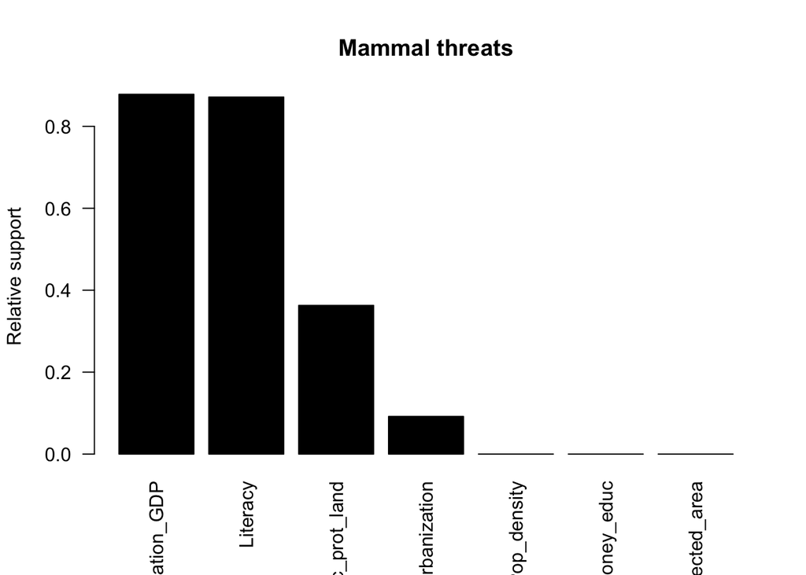

```r
imp.mamm3<-MuMIn::sw(mamm3)
barplot(t(imp.mamm3), main="Mammal threats", col="black", xlab=NULL, ylab="Relative support", las = 2)
```

## Regression trees

Another approach to explore the relative importance of several variables within a model is doing regression trees. This is a simple approach in which the response variable is followed by a classification of the predictor variables

```r
w_tree<-tree(tmamm17~Urbanization+Pop_density+Literacy+education_GDP+money_educ+perc_prot_land+protected_area, data = data, method="class")
summary(w_tree)
```

```
##
## Regression tree:
## tree(formula = tmamm17 ~ Urbanization + Pop_density + Literacy +
##     education_GDP + money_educ + perc_prot_land + protected_area,
##     data = data, method = "class")
## Number of terminal nodes:  14
## Residual mean deviance:  0.3502 = 43.43 / 124
## Distribution of residuals:
##      Min.   1st Qu.    Median      Mean   3rd Qu.      Max.
## -1.878000 -0.288500 -0.001066  0.000000  0.274500  2.094000
```

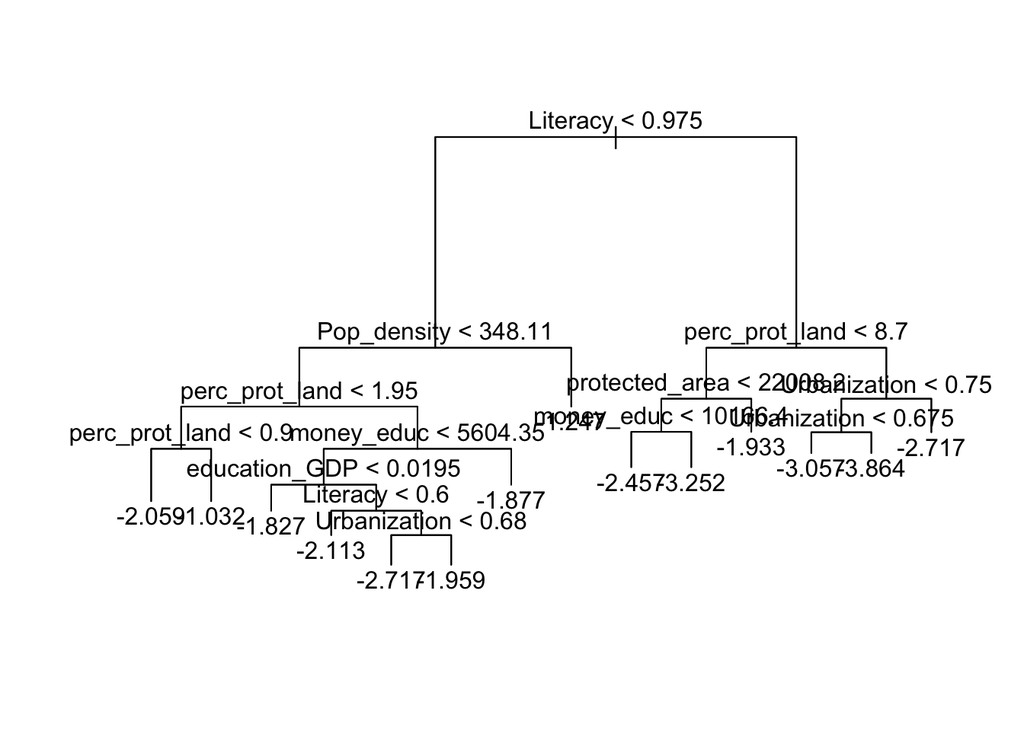

```r
plot(w_tree); text(w_tree)
```

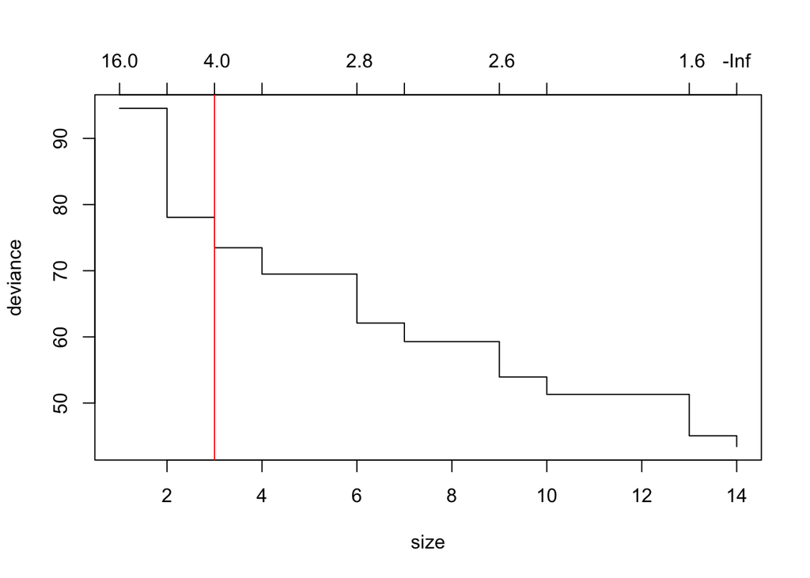

```r
plot(prune.tree(w_tree))
abline(v=3,col="red")
```

As we can see, we have a recursive partitioning with response thresholds of the predictor variables. The second plot indicates the level of significance of the partitioning process.

## Final thoughts

Model averaging and regression trees allow us to determine which variables are important to explain our response variables and which does not. Both approaches are complementary and can give us a more comprehensive picture of the influence of predictor variables in our response.

Licensing Creative Commons License

Licensed under a Creative Commons Attribution-ShareAlike 4.0 International License.  
2025 - Francisco E. Fontúrbel